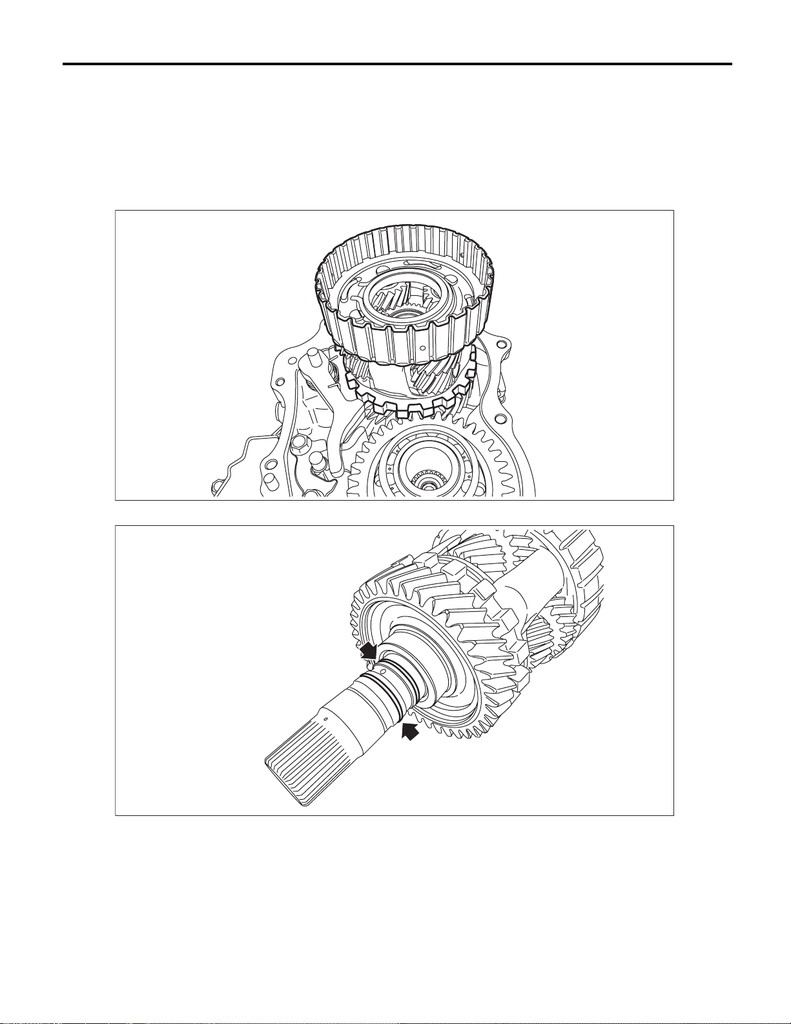

CVT(TR690)-154

Center Differential Carrier

CONTINUOUSLY VARIABLE TRANSMISSION

31.Center Differential Carrier

A: REMOVAL

1) Remove the transmission assembly from the vehicle.

2) Remove the extension case. <Ref. to CVT(TR690)-142, REMOVAL, Extension Case.>

3) Remove the rear drive shaft. <Ref. to CVT(TR690)-146, REMOVAL, Rear Drive Shaft.>

4) Remove the transfer clutch. <Ref. to CVT(TR690)-151, REMOVAL, Transfer Clutch.>

5) Remove the center differential carrier assembly.

6) Remove the seal rings.

AT-07361

AT-07362

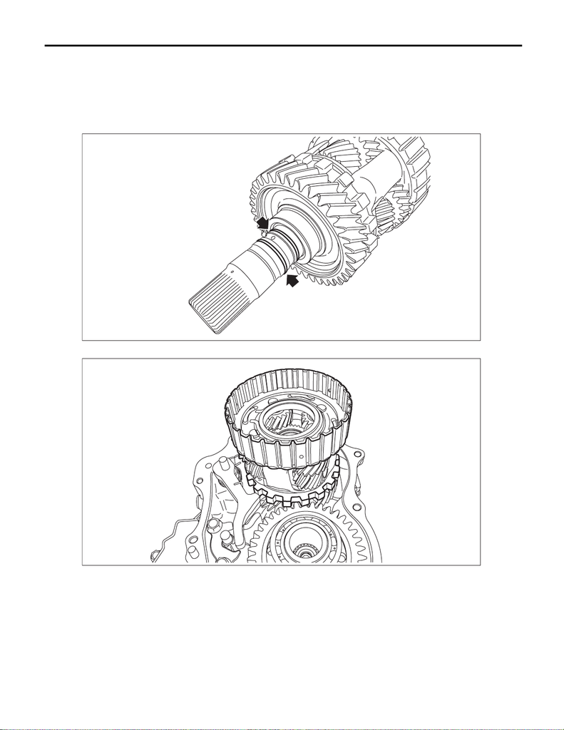

CVT(TR690)-155

Center Differential Carrier

CONTINUOUSLY VARIABLE TRANSMISSION

B: INSTALLATION

1) Install the seal rings.

NOTE:

• Use new seal rings.

• Do not stretch the seal ring excessively.

• Apply CVTF after installation.

2) Install the center differential assembly.

3) Install the transfer clutch. <Ref. to CVT(TR690)-151, INSTALLATION, Transfer Clutch.>

4) Select driven plate No. 3 to replace. <Ref. to CVT(TR690)-152, ADJUSTMENT, Transfer Clutch.>

5) Install the rear drive shaft. <Ref. to CVT(TR690)-146, INSTALLATION, Rear Drive Shaft.>

6) Select the rear drive shaft shim. <Ref. to CVT(TR690)-149, ADJUSTMENT, Rear Drive Shaft.>

7) Install the extension case. <Ref. to CVT(TR690)-143, INSTALLATION, Extension Case.>

8) Install the transmission assembly to the vehicle.

AT-07362

AT-07361

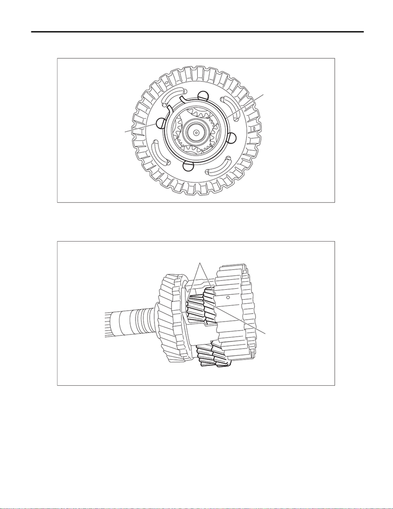

CVT(TR690)-156

Center Differential Carrier

CONTINUOUSLY VARIABLE TRANSMISSION

C: DISASSEMBLY

1) Remove the snap ring, and pull out the pinion shaft from center differential assembly.

2) Remove the pinion gear and washers from center differential assembly.

3) Remove the intermediate shaft and thrust bearing.

(A) Snap ring

(B) Pinion shaft

(A) Pinion gear

(B) Washer

AT-07407

(B)

(A)

AT-07397

(A)

(B)

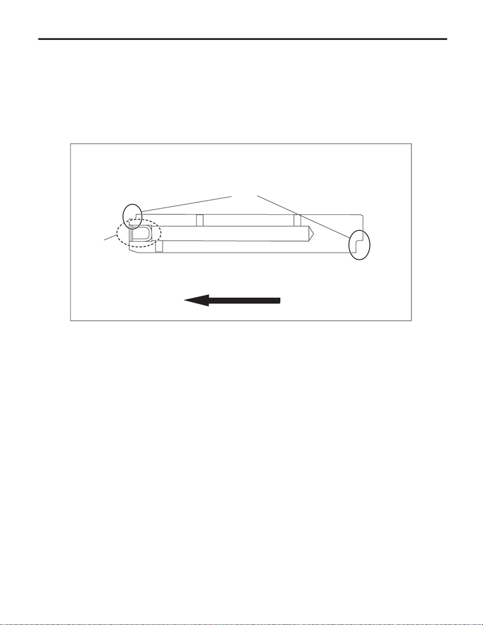

CVT(TR690)-157

Center Differential Carrier

CONTINUOUSLY VARIABLE TRANSMISSION

D: ASSEMBLY

1) Install the thrust bearing onto intermediate shaft.

2) Insert the intermediate shaft into the center differential assembly.

3) Install the pinion gears and washers.

4) Insert the pinion shaft into the center differential assembly.

NOTE:

• Insert the pinion shaft with the side with the plug side facing the front side (gear side).

5) Install the snap ring.

E: INSPECTION

• Check each part for crack, damage, wear or dust.

AT-07408

REAR SIDE (CLUTCH SIDE)

FRONT SIDE (GEAR SIDE)

INSERT DIRECTION

CUTOUT

PLUG